# Analyses speech patterns in daylong recordings (Tsimane village Campo Bello July 2017

# Instructions for use

If this is first time that you are running this script, change the redoALL parameter to TRUE so that the first set of chunks, under generate main databases, is recalculated. Make sure you’ve created a folder called “derivedFiles” inside dalohumacosp, since the databases will be stored in that folder. (The folder is not pushed to github.)

# Generate main databases

## Prep

Convert textgrids into csv’s.

## Reading in current coding

Read in all csv’s and clean up.

## Draw summaries per child & file

The goal is to find out how much clean and overlapping speech there is by all of the speakers, summing within each file. This chunk uses code from https://stackoverflow.com/questions/41839268/sum-overlapping-non-overlapping-time-intervals-in-r by Jonathan von Schroeder.

## Generating Proportions & quantities of CHI vocalizations of different types

## Generating Proportion & quantities of FA1 linguistic vocalizations

## Generating Proportion & quantities of FA1 linguistic vocalizations

# Finally put in this document all the graphs you have done, you are overwritten them you idiot

```r
load
```

[output not shown]

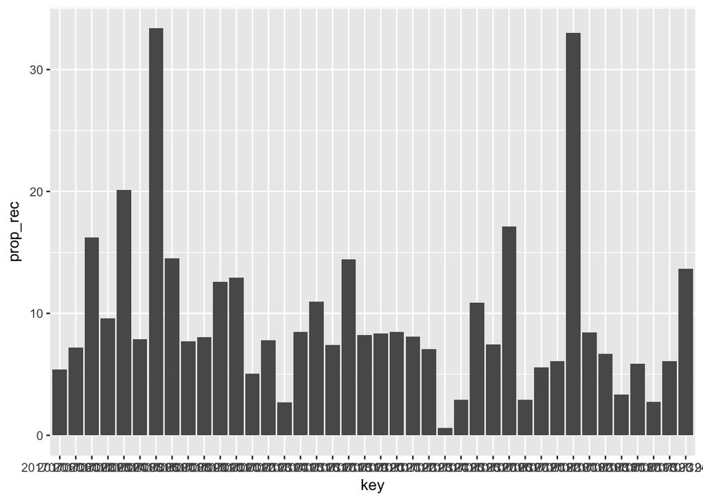

```r
library(ggplot2)
library(likert)
library(reshape2)
library(RColorBrewer)
library(dplyr)
library(ggthemes)
library(stringr)

read.table("~/Documents/tsimane_project/dalohumacosp/derivedFiles/min_perID.txt",header=T) -> sumdur

# create a dataset
#examples:
# specie=c(rep("sorgho" , 3) , rep("poacee" , 3) , rep("banana" , 3) , rep("triticum" , 3) )
# condition=rep(c("normal" , "stress" , "Nitrogen") , 4)
# value=abs(rnorm(12 , 0 , 15))
# data=data.frame(specie,condition,value)
#Data set without noise
sumdur$child_age=paste0(sumdur$age_mo,sumdur$child)
sumdur$child_age[sumdur$child=="C13"] <- "06C13"
sumdur$child_age[sumdur$child=="C14"] <- "08C14"
sumdur$child_age[sumdur$child=="C25"] <- "08C25"

#try liker


# Grouped
ggplot(subset(sumdur,speakerID != "Noise"), aes( y=prop_rec, x=key)) +
  geom_bar(position="dodge", stat="identity")
```

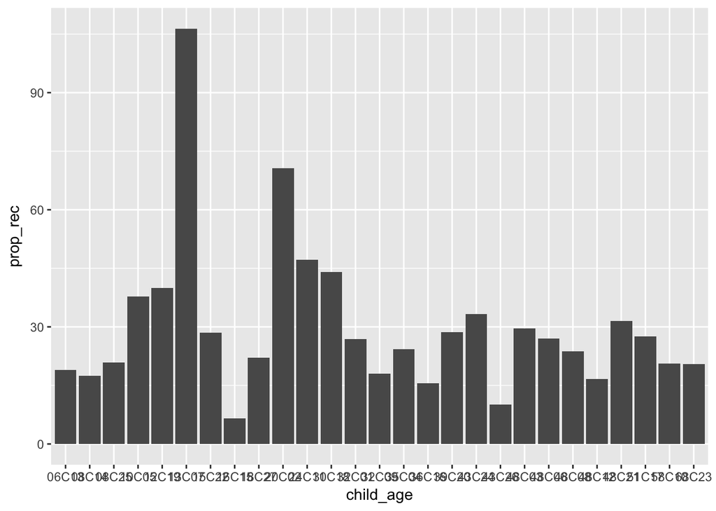

```r
# Stacked
ggplot( subset (sumdur, speakerID %in% c("FA1", "FA2", "FA3", "MA1", "MA2", "UC1", "UC2", "SP")), aes(y=prop_rec, x=child_age)) +
  geom_bar( stat="identity")
```

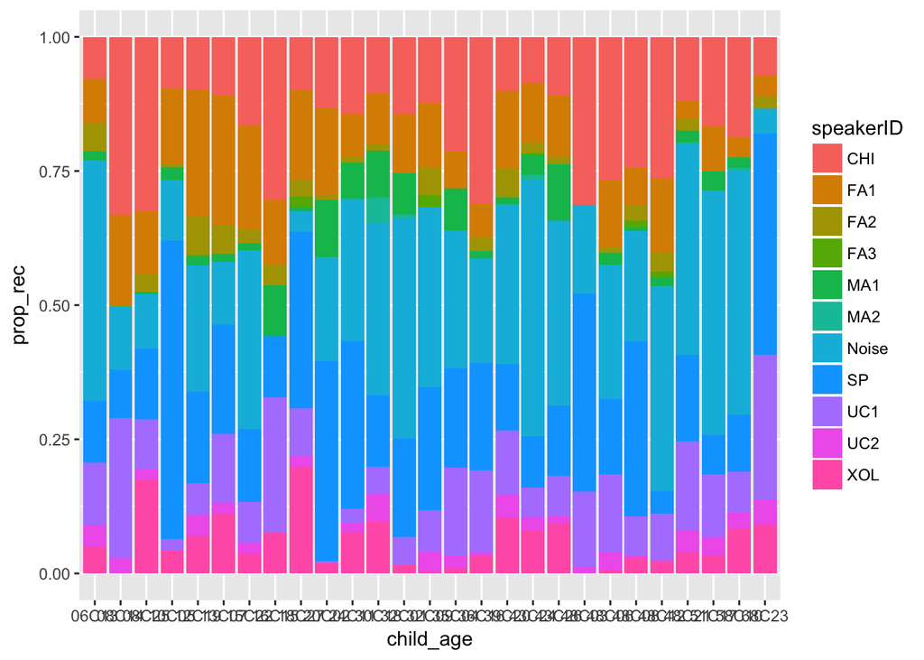

```r
# Stacked Percent
ggplot(sumdur, aes(fill=speakerID, y=prop_rec, x=child_age)) +
  geom_bar( stat="identity", position="fill")
```

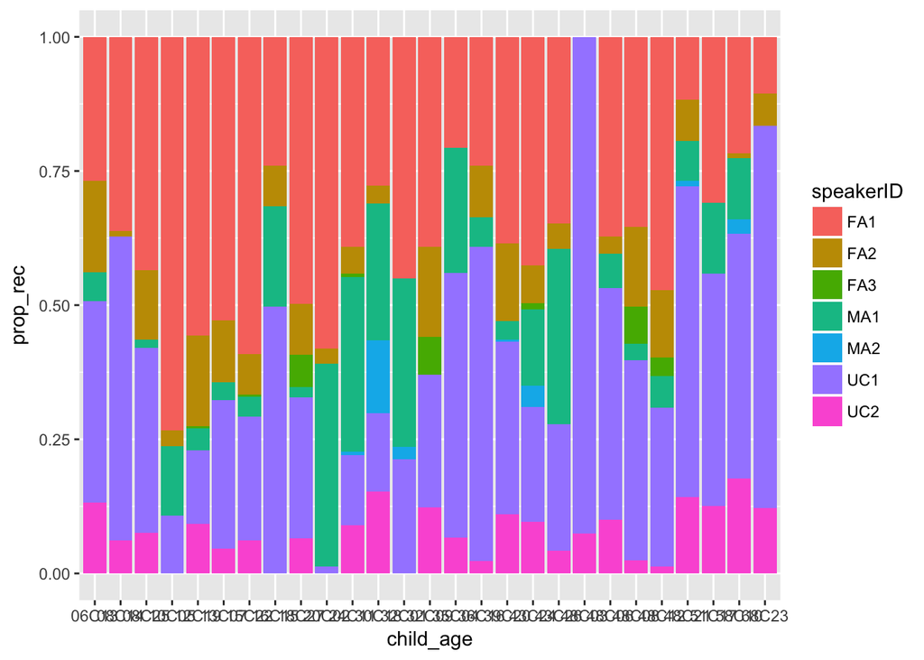

```r
#only consider input
ggplot(subset(sumdur,speakerID %in% c("FA1", "FA2", "FA3", "MA1", "MA2", "UC1", "UC2")), aes(fill=speakerID, y=prop_rec, x=child_age)) +
  geom_bar( stat="identity", position="fill")
```

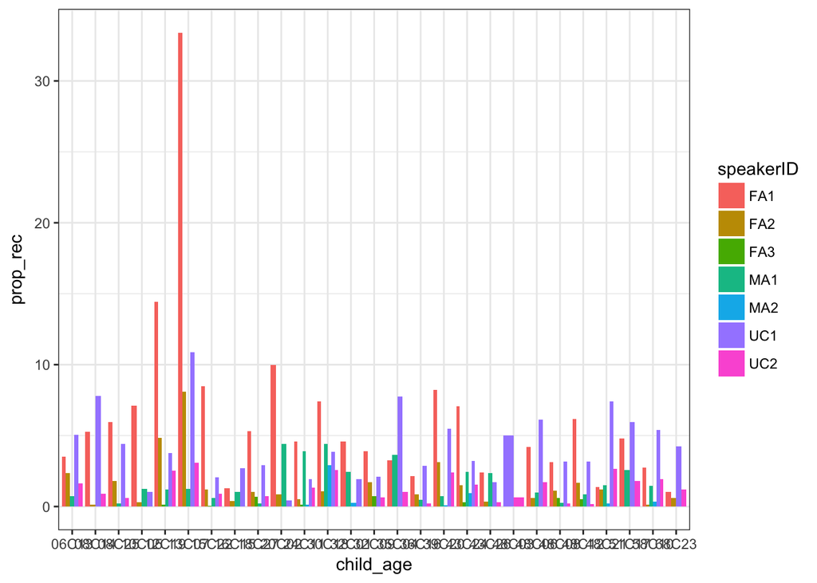

```r
#
ggplot() +
  geom_bar(data=subset(sumdur,speakerID %in% c("FA1", "FA2", "FA3", "MA1", "MA2", "UC1", "UC2")), aes(y = prop_rec, x = child_age, fill = speakerID), stat="identity",position='dodge') +
  theme_bw()
```

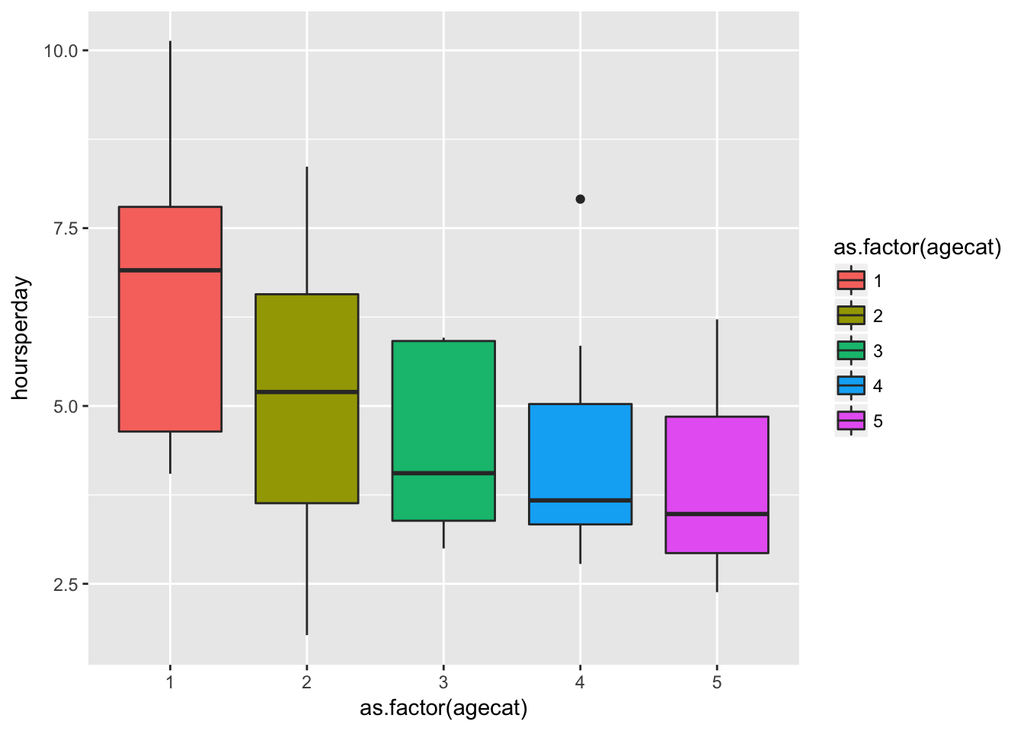

```r
read.table("~/Documents/tsimane_project/dalohumacosp/derivedFiles/tot_suminput.txt",header=T) -> tot_suminput

#hours per day as a function of age
ggplot(tot_suminput, aes(x=as.factor(agecat), y= hoursperday, fill=as.factor(agecat)) ) + geom_boxplot()
```

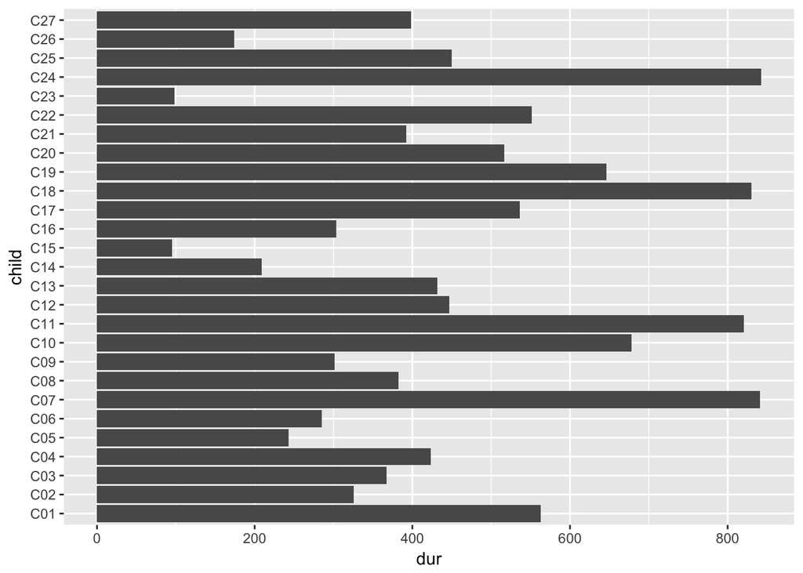

```r
#Alex examples of conditional syntax for R
# x[(x$a=="äa" | x$a=="b") & x$y==1,]
# x[ x$a %in% c("äa","b") & x$y==1,]
read.table("~/Documents/tsimane_project/dalohumacosp/derivedFiles/line_per_segment_age.txt",header=T)->all



ggplot(all, aes(x = child, y = dur)) +     geom_bar(stat = "identity") +     coord_flip()
```

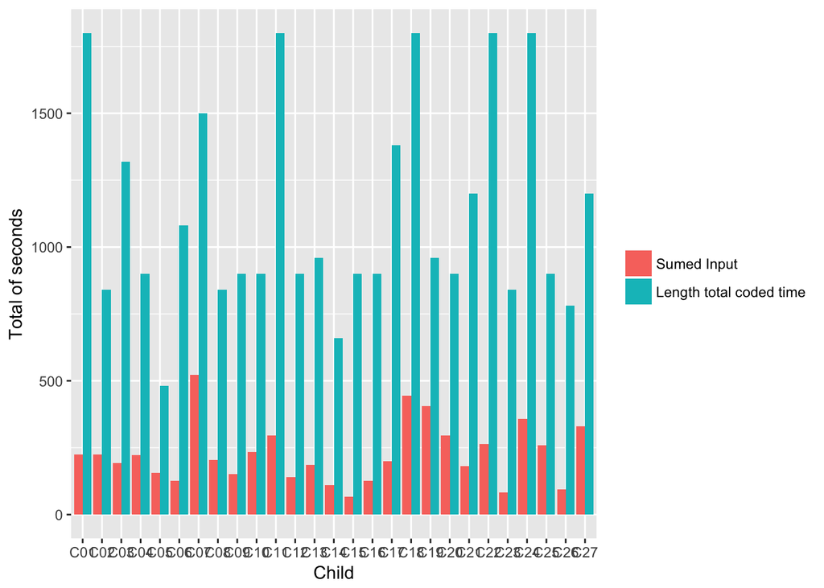

```r
#Create dataframe that paste sec_coded column and totdur_sum so it you can plot the total time next to the one having vocalizations// conceptually it doesnt make any sense // i know
dfm <- melt(tot_suminput[,c('child','totdur_sum','sec_coded')],id.vars = 1)
ggplot(dfm, aes(x=child, y=value)) + geom_bar(aes (fill= variable), stat = "identity", position = "dodge") + labs(x="Child", y="Total of seconds") + guides(fill=guide_legend(title=NULL)) + scale_fill_discrete(labels= c("Sumed Input", "Length total coded time"))
```

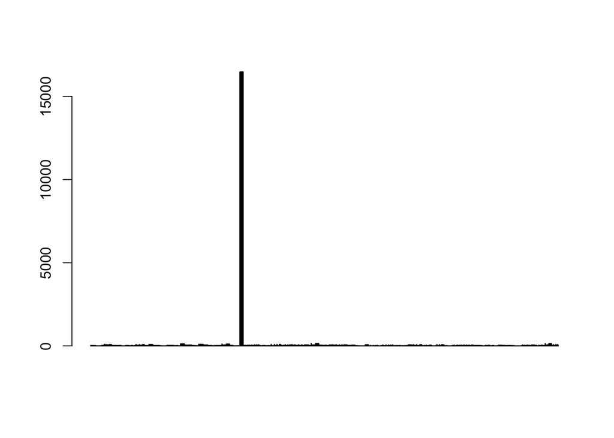

```r
#summary per day
barplot(sums$dur)
```

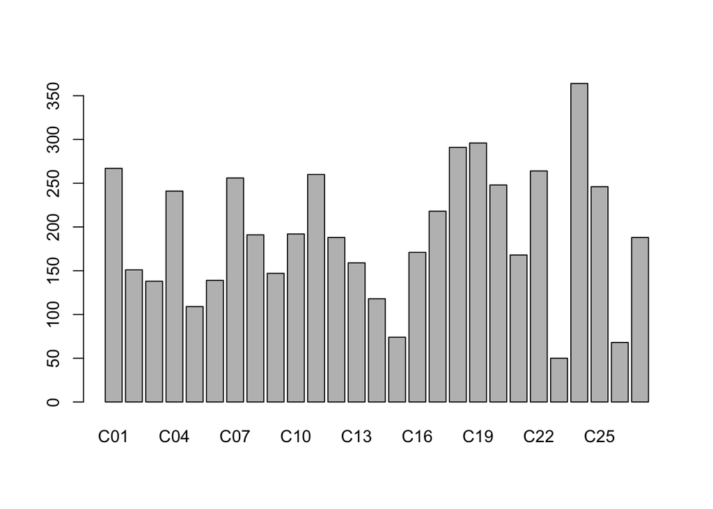

```r
#summary per child
barplot(summary(all$child))
```

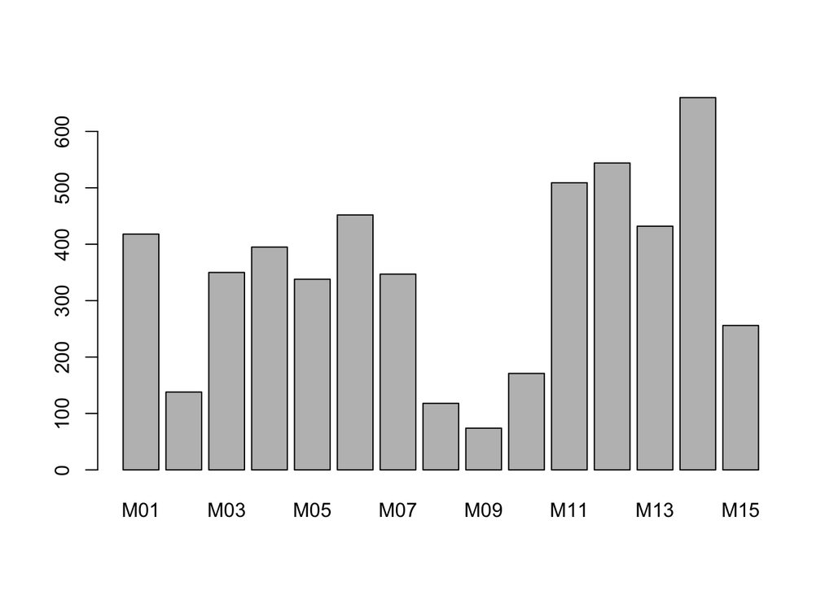

```r
#summary per mom
barplot(summary(all$mot))
```

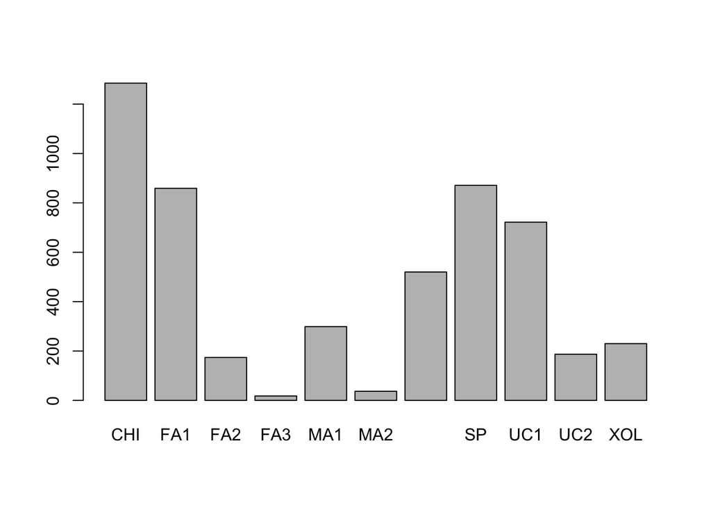

```r
#summary per speaker ID
barplot(summary(as.factor(all$speakerID)))
```

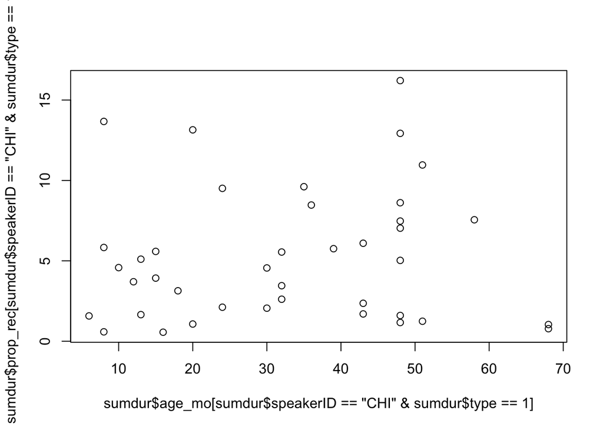

```r
#plot of ling voc as a function of age
plot(sumdur$age_mo[sumdur$speakerID=="CHI" & sumdur$type==1], sumdur$prop_rec[sumdur$speakerID=="CHI" & sumdur$type==1])
```

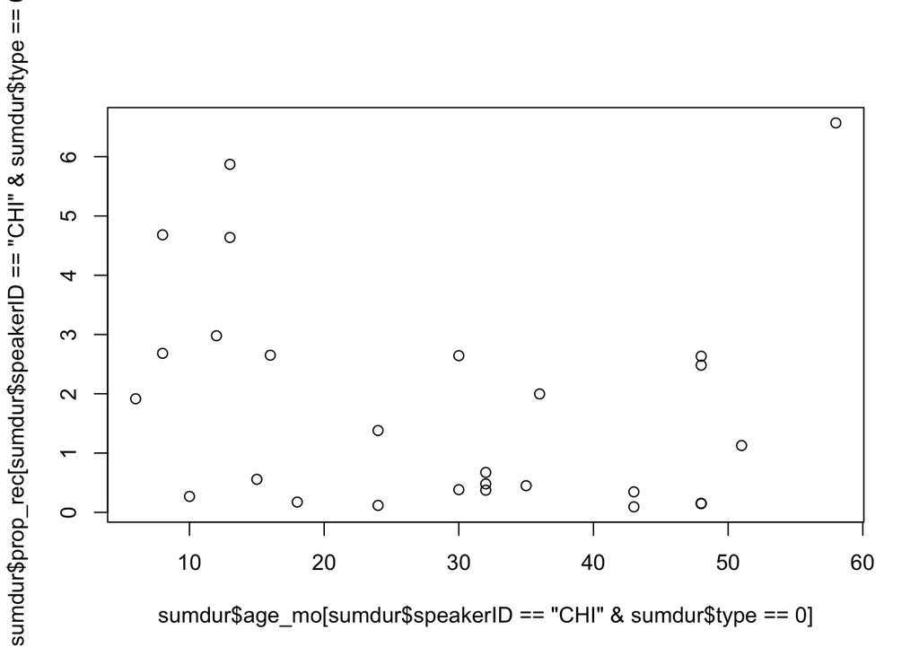

```r
plot(sumdur$age_mo[sumdur$speakerID=="CHI" & sumdur$type==0], sumdur$prop_rec[sumdur$speakerID=="CHI" & sumdur$type==0])
```

```r
summary (cor(sumdur$age_mo[sumdur$speakerID=="CHI" & sumdur$type==1], sumdur$prop_rec[sumdur$speakerID=="CHI" & sumdur$type==1]))
```

```
##    Min. 1st Qu.  Median    Mean 3rd Qu.    Max.
## 0.07924 0.07924 0.07924 0.07924 0.07924 0.07924
```

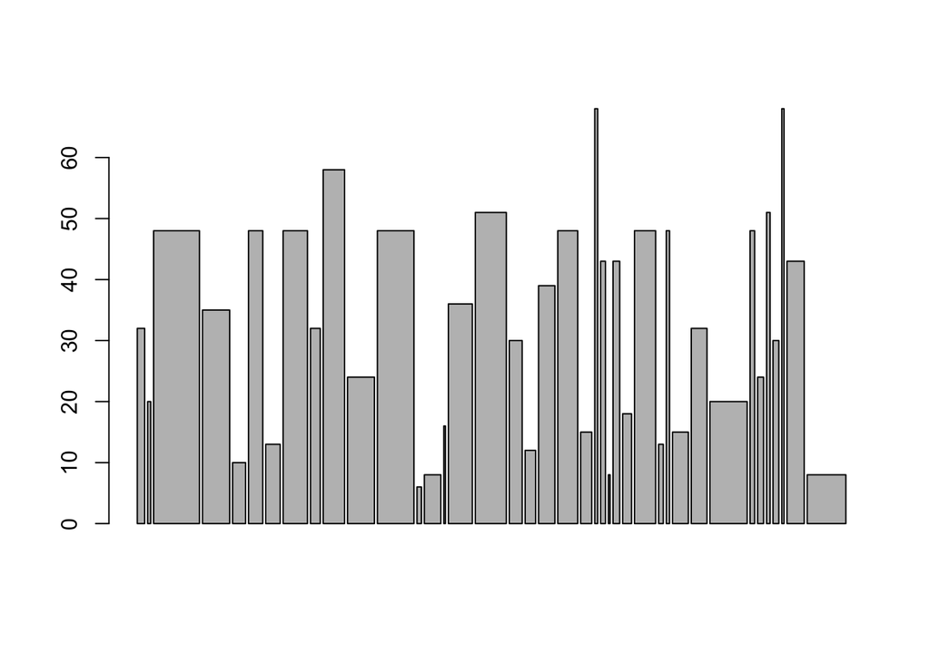

```r
barplot(sumdur$age_mo[sumdur$speakerID=="CHI" & sumdur$type==1], sumdur$prop_rec[sumdur$speakerID=="CHI" & sumdur$type==1])
```

# Methodological analyses

## How much data are there?

We read in the version of the file that has one line per coded segment. That is, if the child vocalized 3 times in a given minute, an adult 2 times, and another child once, then there will be 6 segments for that *minute*. This is the most fine-grained format of representation, and thus too fine-grained for some of the quantification questions we have. So we will derive tables as needed.

First, we look at how many coded minutes there are for each child and date.

```r
read.table("~/Documents/tsimane_project/dalohumacosp/derivedFiles/line_per_segment_age.txt",header=T)->all
levels(all$child)-> kids
levels(all$key)-> days

#number of coded minutes per child
data.frame(table(all$key,all$min_coded))->x
x[x$Freq!=0,]->x

#number of coded days per child
data.frame(table(all$child,all$key))->y
y[y$Freq!=0,]->y
```

There are 27 in all. There are a total of 40 days coded. Number of days coded per children (C10 actually had also her second day coded but the Praat file was damaged? :

```r
table(y$Var1)
```

```
##
## C01 C02 C03 C04 C05 C06 C07 C08 C09 C10 C11 C12 C13 C14 C15 C16 C17 C18
##   2   2   2   1   1   2   2   1   1   1   2   1   1   1   1   1   2   2
## C19 C20 C21 C22 C23 C24 C25 C26 C27
##   1   1   2   2   2   2   2   1   1
```

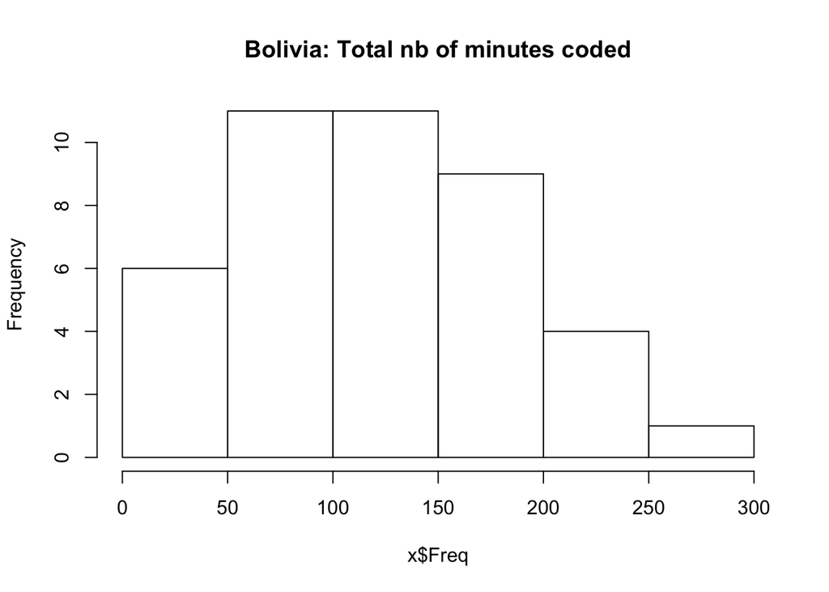

```r
hist(x$Freq,main="Bolivia: Total nb of minutes coded")
```

This table doesnt show that : 1, 1, 1, 1, 1, 1, 1, 1, 1, 1, 1, 2, 1, 1, 1, 1, 1, 1, 1, 1, 1, 2, 2, 1, 1, 1, 1, 1, 1, 1, 1, 1, 1, 1, 1, 1, 1, 1, 1

# Theory-relevant analyses

```r
dokidageplot<-function(sumchi,dvname,fancydvname){
  #dvname="prop";fancydvname="prop"
  mycols=ifelse(substr(sumchi$child,1,1)=="v","red","blue")
  plot(sumchi[,dvname]~sumchi$age_mo,type="n",main=fancydvname,xlab="Age (months)",ylab=dvname)
for(kidag in levels(factor(sumchi$child_age))){
  age=mean(sumchi$age_mo[sumchi$child_age==kidag],na.rm=T)
  prop=mean(sumchi[sumchi$child_age==kidag,dvname],na.rm=T)
  err=sd(sumchi[sumchi$child_age==kidag,dvname],na.rm=T)
  text(age,prop,substr(kidag,1,3),col=mycols)
  lines(c(age,age),c(prop-err,prop+err),col="gray")
}

for(kid in levels(factor(sumchi$child))){
  props = aggregate(sumchi[sumchi$child==kid,dvname],by=list(sumchi$age_mo[sumchi$child==kid]),mean,na.rm=T)
  for(thisline in 1:(dim(props)[1]-1)) lines(c(props$Group.1[thisline],props$Group.1[thisline+1]),c(props$x[thisline],props$x[thisline+1]),lty=2,col=ifelse(substr(kid,1,1)=="v","red","blue"))
}

    plot(sumchi[,dvname]~sumchi$age_mo,cex=(sumchi[,dvname]/max(sumchi[,dvname],na.rm=T)),main="Data per recording day",xlab="Age (months)",ylab=dvname)
text(sumchi$age_mo,sumchi[,dvname],as.character(sumchi$child),cex=.5,pos=4,col=mycols)

}
```

In all of the following analyses, we will consider four possible dependent measures, all of which control for the fact that we have a lot more coded data for some kids than others:

```
- The quantity of linguistic vocalizations (controlling for recording length)
- The quantity of non-linguistic vocalizations (controlling for recording length)
- The quantity of vocalizations (summing linguistic and non-linguistic) (controlling for recording length)
- The proportion of vocalizations that are linguistic, out of all vocalizations
```

When we say controlling for recording length we mean that these are proportions of the time that has been coded where CHI produces ling vocs. For instance, if kid produced 200 secs of ling vocalizations in a given day, of which 1000 secs have been coded, then they will show up below as .2. We don’t need to do that for the last DV, since the length of vocalizations is already in the denominator.

## How much does CHI vocalize as a function of age?

Focus on linguistic vocalizations:

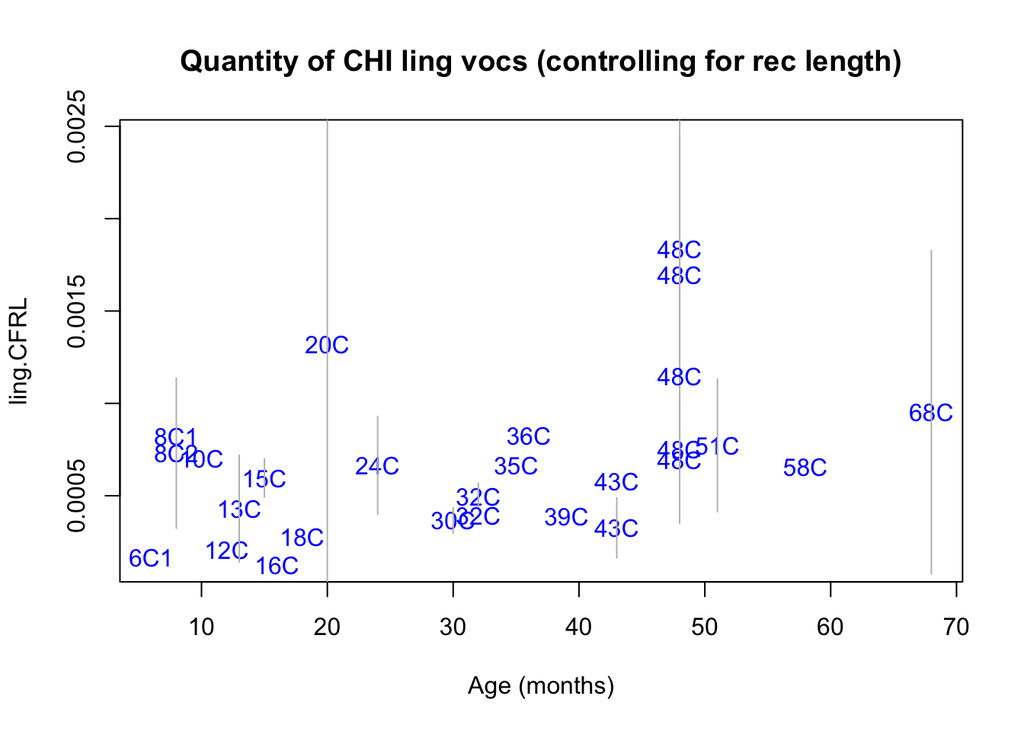

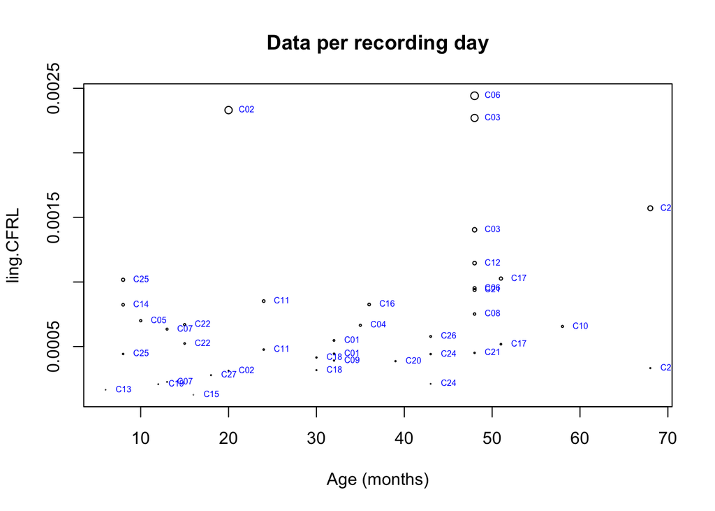

```r
read.table("~/Documents/tsimane_project/dalohumacosp/derivedFiles/propling_age.txt",header=T)->sumchi

dokidageplot(sumchi,"ling.CFRL","Quantity of CHI ling vocs (controlling for rec length)")
```

Now non-linguistic vocalizations:

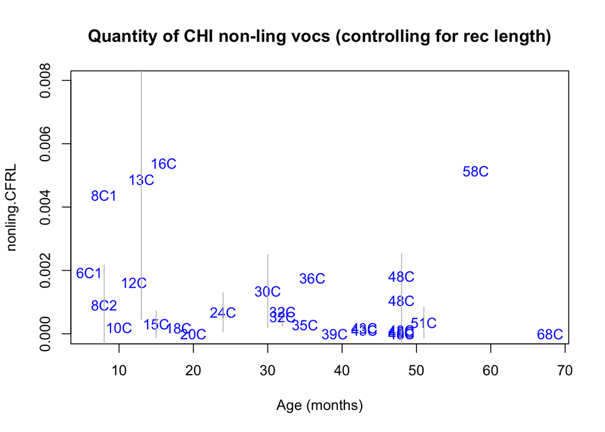

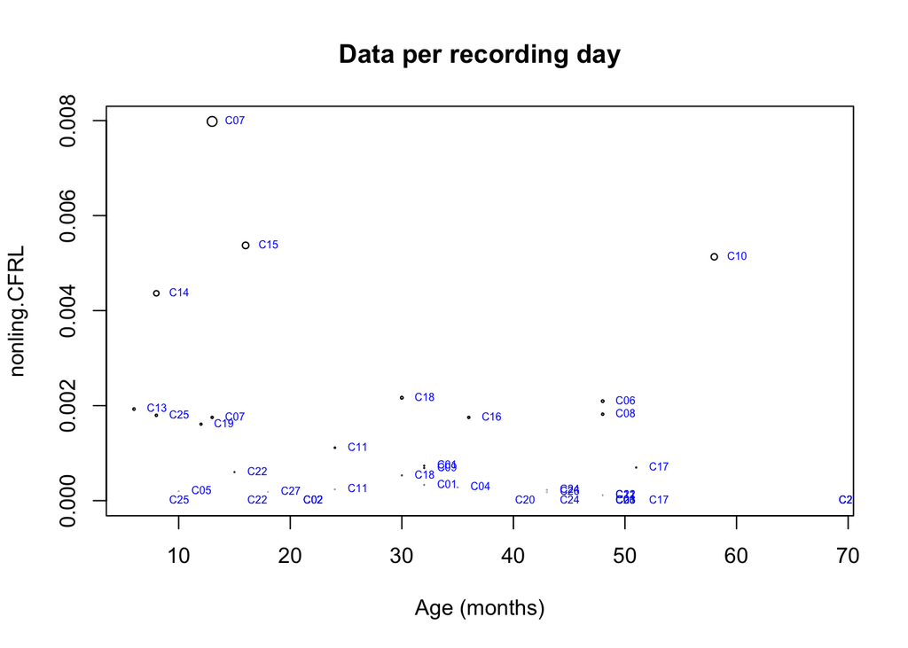

```r
dokidageplot(sumchi,"nonling.CFRL","Quantity of CHI non-ling vocs (controlling for rec length)")
```

Now total vocalizations:

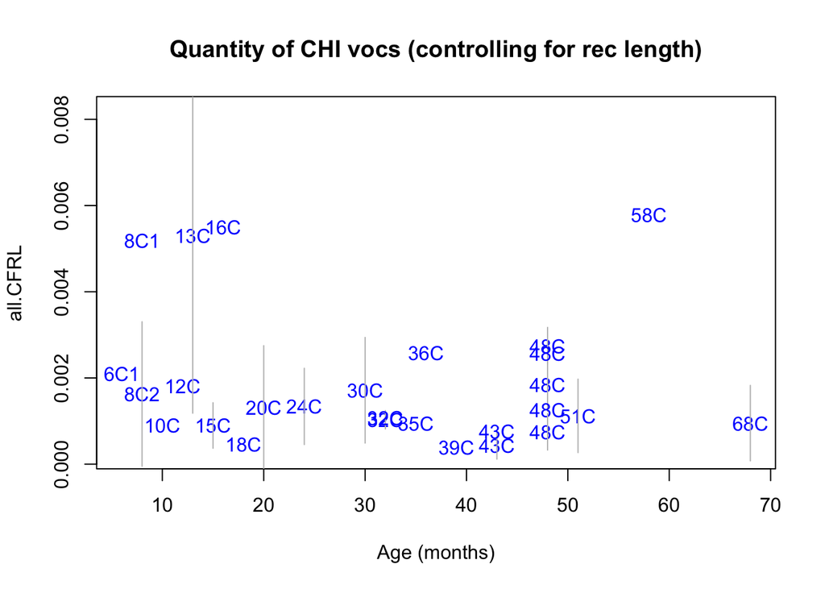

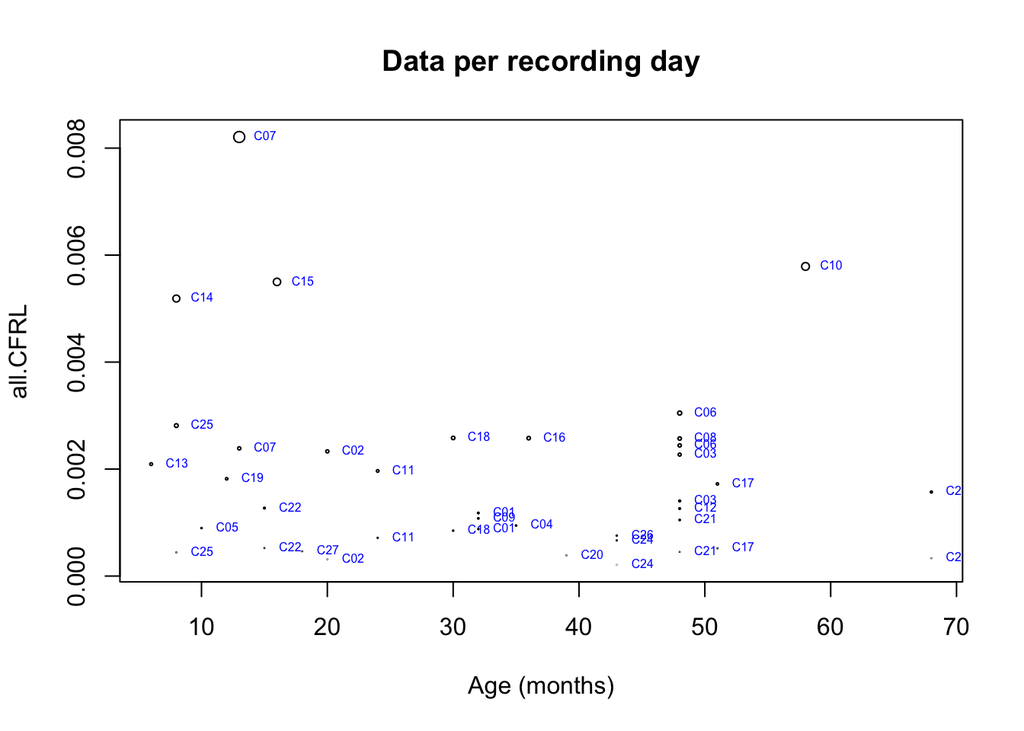

```r
dokidageplot(sumchi,"all.CFRL","Quantity of CHI vocs (controlling for rec length)")
```

And finally, the ratio of ling to all vocs:

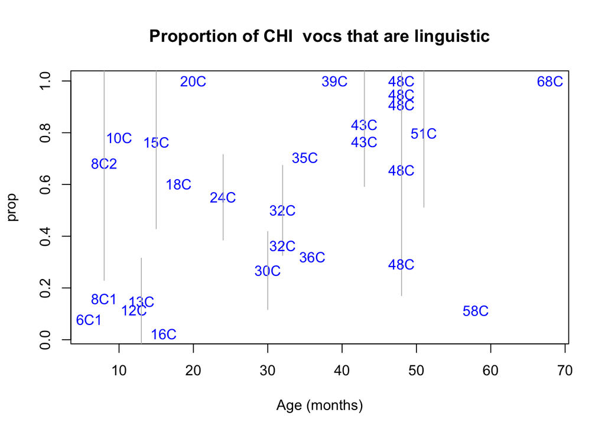

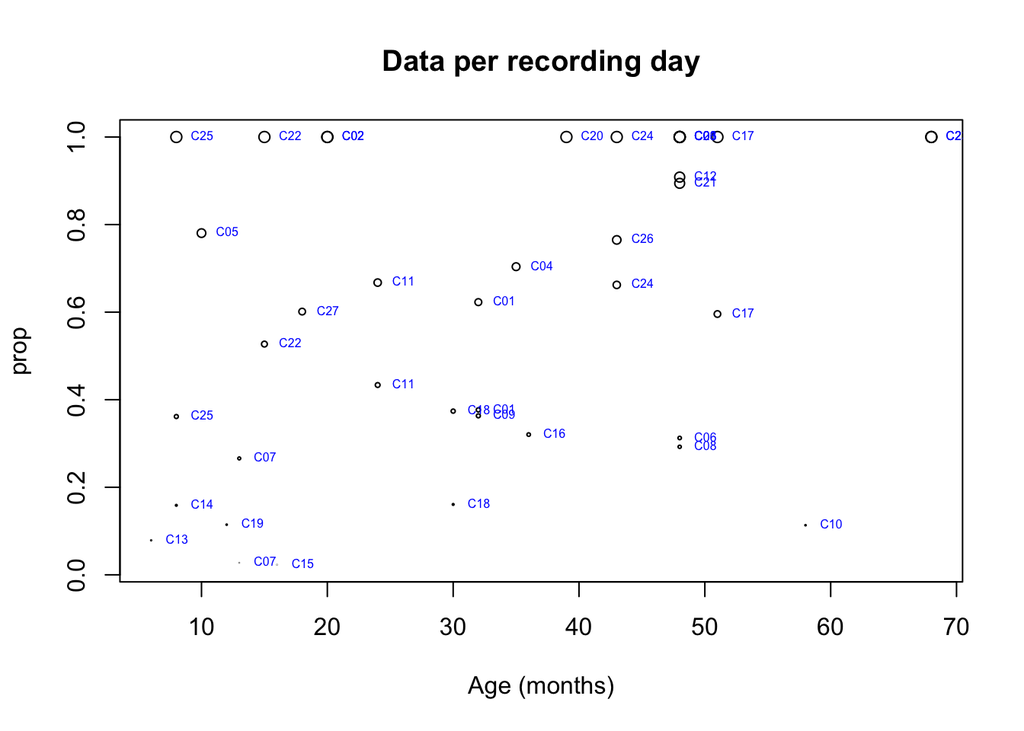

```r
dokidageplot(sumchi,"prop","Proportion of CHI  vocs that are linguistic")
```

## How much does MOTHER vocalize as a function of age?

Focus on linguistic vocalizations:

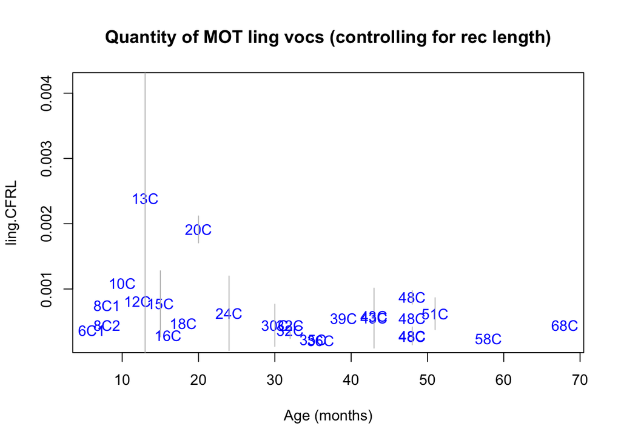

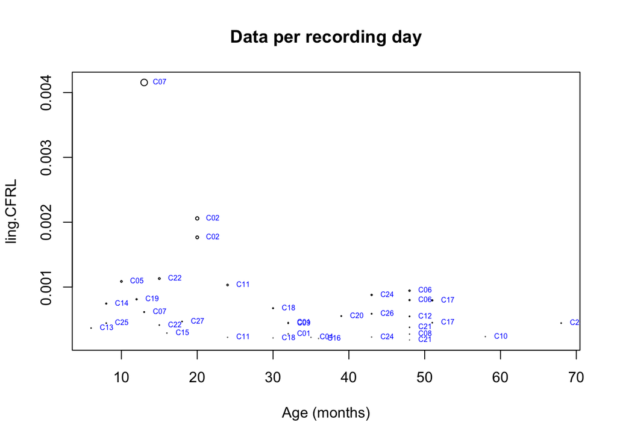

```r
read.table("~/Documents/tsimane_project/dalohumacosp/derivedFiles/propling_age_MOT.txt",header=T)->summot


dokidageplot(summot,"ling.CFRL","Quantity of MOT ling vocs (controlling for rec length)")
```

Now total vocalizations:

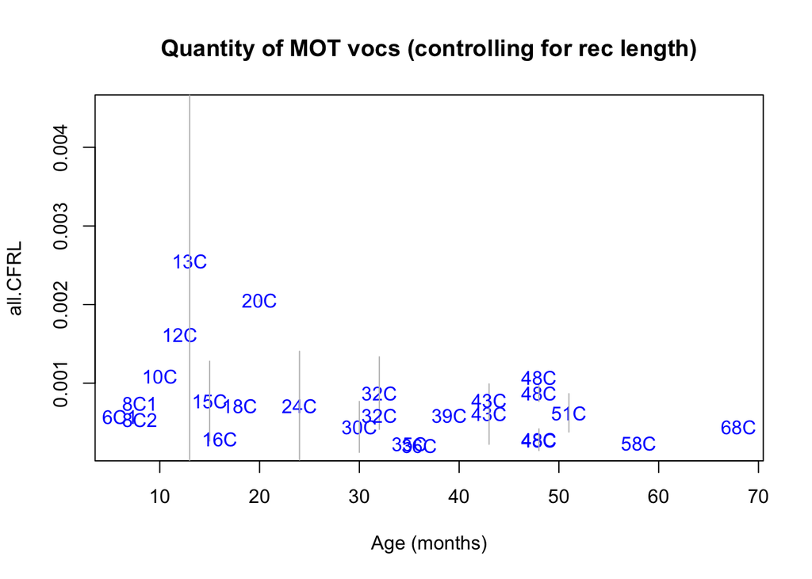

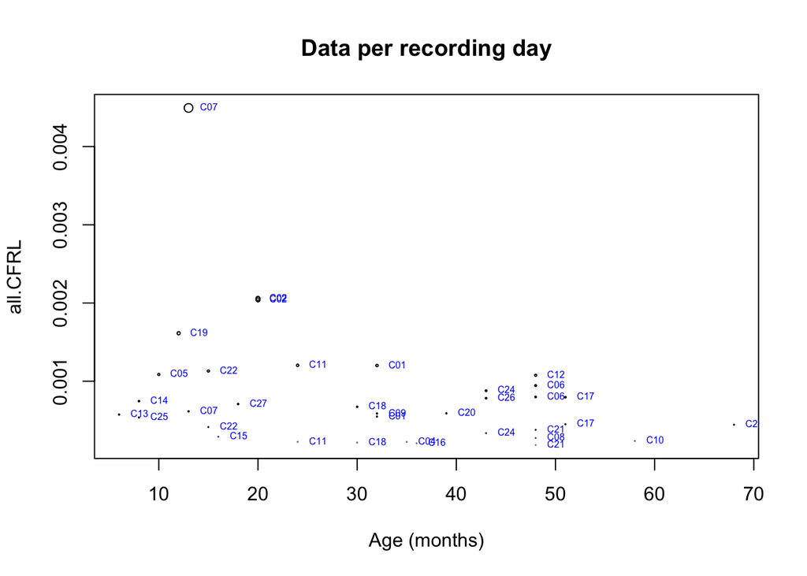

```r
dokidageplot(summot,"all.CFRL","Quantity of MOT vocs (controlling for rec length)")
```

## How much input is there, as a function of age?

Since overheard versus child-directed has not yet been coded, this is total input

```r
read.table("~/Documents/tsimane_project/dalohumacosp/derivedFiles/line_per_chunk.txt",header=T)->sums

aggregate(sums$dur,by=list(sums$key,sums$source,sums$maxtot,sums$age_mo),sum,na.rm=T)->sum_visit
colnames(sum_visit)<-c("key","source","maxtot","age","tot")
sum_visit$tot.CFRL=sum_visit$tot/sum_visit$maxtot

all_sources=as.character(levels(sum_visit$source))
nonCHI=all_sources[-grep("CHI",all_sources)]

nonOL=all_sources[-grep(" ",all_sources)]
nonOL=nonOL[-grep("XOL",nonOL)]
nonOLnonCHI=nonOL[-grep("CHI",nonOL)]



aggregate(sum_visit$tot.CFRL[sum_visit$source %in% nonOLnonCHI],by=list(sum_visit$key[sum_visit$source %in% nonOLnonCHI],sum_visit$age[sum_visit$source %in% nonOLnonCHI]),sum)->tot_talking_nonOL
colnames(tot_talking_nonOL)<-c("key","age","tot")

aggregate(sum_visit$tot.CFRL[sum_visit$source %in% nonCHI],by=list(sum_visit$key[sum_visit$source %in% nonCHI],sum_visit$age[sum_visit$source %in% nonCHI]),sum)->tot_talking
colnames(tot_talking)<-c("key","age","tot")


plot(tot_talking$tot ~ tot_talking$age,col=ifelse(substr(as.character(tot_talking$key),7,7)=="v","red","blue"),main="Total non-CHI talking with overlap")

plot(tot_talking_nonOL$tot ~ tot_talking_nonOL$age,col=ifelse(substr(as.character(tot_talking$key),7,7)=="v","red","blue"),main="Total non-CHI talking, NO overlap")
```

[output not shown]

## How much of the input comes from mother versus other adults versus other kids?

```r
aggregate(sum_visit$tot.CFRL[sum_visit$source %in% nonOLnonCHI],by=list(sum_visit$key[sum_visit$source %in% nonOLnonCHI],sum_visit$source[sum_visit$source %in% nonOLnonCHI],sum_visit$age[sum_visit$source %in% nonOLnonCHI]),sum)->tot_talking_nonOL
colnames(tot_talking_nonOL)<-c("key","source","age","tot")

aggregate(sum_visit$tot.CFRL[sum_visit$source %in% nonCHI],by=list(sum_visit$key[sum_visit$source %in% nonCHI],sum_visit$source[sum_visit$source %in% nonCHI],sum_visit$age[sum_visit$source %in% nonCHI]),sum)->tot_talking
colnames(tot_talking)<-c("key","source","age","tot")
```

## Is there a relationship between input quantity and output quantity?

# TO DO:

- identify what I could possibly have meant by: “CHI. voc auqntm speech auqntm ratio”
- add recording onset time
- only then describe quant over hours